# Groepsopdracht 2 — AI als assistent

Hoe gebruik je AI prompts op een goede manier

Author

Affiliation

Gerko Vink

Methodology & Statistics @ Utrecht University

# Structuur

| Onderdeel | Beschrijving |
| --- | --- |
| **Duur** | 1 uur |
| **Werkvorm** | Groepswerk in groepen van 3–4 studenten. Het is wenselijk dat je met verschillende inhoudelijke interesses in één groep zit, zodat jullie van elkaar kunnen leren. Twee weten immers meer dan één! |

# Doel van de opdracht

In deze opdracht gebruiken jullie een AI-tool als onderzoeksassistent. Het doel is niet om AI blind te vertrouwen, maar om te ervaren hoe de kwaliteit van een AI-antwoord verandert wanneer je betere instructies geeft, kritischer doorvraagt en de output systematisch beoordeelt. De opdracht helpt jullie om later hetzelfde proces toe te passen op literatuur voor je eigen onderzoeksproject.

Jullie werken met het artikel:

[Oberman, H. I., & Vink, G. (2024). Toward a standardized evaluation of imputation methodology. Biometrical Journal, 66, 2200107](https://onlinelibrary.wiley.com/doi/full/10.1002/bimj.202200107)

Dit artikel bespreekt waarom er meer standaardisatie nodig is bij het evalueren van imputatie methodologie. Het laat zien dat keuzes in simulatieopzet, data-generatie, missingness-generatie en performance-evaluatie grote invloed kunnen hebben op de conclusies over de kwaliteit van imputatie methoden.

# Wat heb je nodig

- Het artikel van Oberman & Vink over evaluatie van imputation methodology
- Een AI-tool naar keuze
- Toegang tot internet of een wetenschappelijke zoekmachine
- Zotero, met eventueel de Zotero browser connector
- Een gedeeld document waarin je groep de antwoorden noteert

# De opdracht

## Stap 1: Begin met een minimale prompt

Open een AI-tool en geef alleen de volgende prompt:

*Summarize this in 200 words.*

Gebruik hierbij de tekst of PDF van het artikel.

Lees de output kritisch. Bespreek in je groep:

- Is de samenvatting inhoudelijk correct?
- Is duidelijk wat het doel van het artikel is?
- Worden de belangrijkste onderdelen van het artikel genoemd?
- Is duidelijk voor welk publiek de samenvatting bedoeld is?
- Worden beperkingen, context of kernbegrippen goed uitgelegd?
- Zijn er uitspraken die te algemeen, vaag of mogelijk onjuist zijn?

Noteer kort wat goed is aan de samenvatting en wat ontbreekt.

## Stap 2: Maak de prompt beter met BRAVE(R)

Nu bouw je de prompt opnieuw op. Gebruik hiervoor de BRAVE(R)-techniek zoals besproken in het college. Het doel is om AI niet alleen te vragen om “een samenvatting”, maar om een beter gesitueerde, controleerbare en bruikbare academische output te maken.

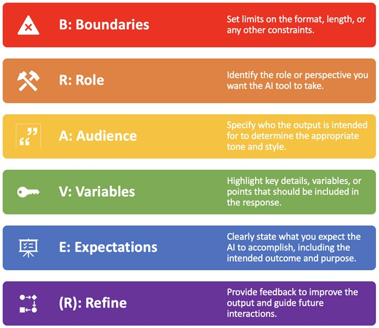

Gebruik de volgende onderdelen als houvast:

| Onderdeel | Betekenis | Vraag die je jezelf stelt |
| --- | --- | --- |
| –B — Boundaries– | Grenzen en randvoorwaarden | Welke grenzen stel je aan de output, zoals lengte, format, taal, detailniveau of beperkingen? |
| –R — Role– | Rol of perspectief | Welke rol moet de AI aannemen, bijvoorbeeld statisticus, methodoloog, reviewer of onderzoeksassistent? |
| –A — Audience– | Doelgroep | Voor wie is de output bedoeld, en welke toon, stijl en voorkennis passen daarbij? |
| –V — Variables– | Belangrijke details | Welke kernbegrippen, variabelen, onderdelen of aandachtspunten moeten zeker worden meegenomen? |
| –E — Expectations– | Verwachte uitkomst | Wat moet de AI precies opleveren, met welk doel en in welke vorm? |
| –(R) — Refine– | Verbeteren en bijsturen | Welke feedback geef je om de output te verbeteren of een volgende versie scherper te maken? |

Maak nu samen een betere prompt. De prompt moet in ieder geval duidelijk maken dat:

- de samenvatting ongeveer 200 woorden moet zijn
- de output academisch, maar begrijpelijk moet zijn
- de AI optreedt als onderzoeksassistent of methodologisch adviseur
- de samenvatting bedoeld is voor masterstudenten Applied Statistics
- de kernbijdrage van het artikel moet worden uitgelegd
- begrippen zoals inference, prediction, simulation design, missingness generation en performance evaluation waar relevant moeten worden meegenomen
- de samenvatting geen ongecontroleerde claims mag bevatten
- de AI na afloop kort moet aangeven welke onderdelen mogelijk gecontroleerd moeten worden in de originele tekst.

**TipHINT: Voorbeeld van een betere prompt:**

You are acting as a methodological research assistant for master students in Applied Statistics.

Summarize the attached article by Oberman and Vink in approximately 200 words. The summary should be written in clear academic English for students who understand basic statistics but are not yet experts in missing data methodology.

The summary should explain the main problem, the purpose of the article, the central argument, and the practical relevance for evaluating imputation methods. Include, where relevant, the distinction between statistical inference and prediction, and mention why simulation design, missingness generation, and performance measures matter.

Do not invent details that are not in the article. Avoid unnecessary jargon. After the summary, list three points that should be checked in the original article before the summary is used in a report.

Voer jullie verbeterde prompt uit en vergelijk de nieuwe samenvatting met de samenvatting die jullie eerst hadden.Vergelijk deze prompt met de eerste prompt: -Summarize this in 200 words-. Bespreek in je groep:

- Welke grenzen zijn nu duidelijker?
- Welke rol heeft de AI gekregen?
- Voor welk publiek is de samenvatting geschreven?
- Welke belangrijke variabelen, begrippen of onderdelen zijn toegevoegd?
- Wat is de verwachte output?
- Welke vervolgvraag of feedback zou je geven om de samenvatting verder te verbeteren?

## Stap 3: Beoordeel de AI-output met RACCCA

Gebruik nu -RACCCA- om de samenvatting te beoordelen. Het doel is om niet alleen te kijken of de tekst mooi klinkt, maar of de inhoud bruikbaar is voor wetenschappelijk werk. Gebruik hiervoor de volgende beoordelingsvragen:

| Criterium | Vraag |
| --- | --- |
| –R — Relevance– | Beantwoordt de output de vraag die gesteld is of de opdracht die gegeven is? |
| –A — Accuracy– | Geeft de output correcte, betrouwbare informatie die gebaseerd is op feiten? -Dit betekent dat de correctheid van de output wordt gecontroleerd door de tekst te vergelijken met andere bronnen-. |
| –C — Completeness– | Zijn de belangrijkste onderdelen en aspecten van het onderwerp of de vraag voldoende meegenomen? |
| –C — Clarity– | Is de tekst helder en begrijpelijk? Is de output ook gemakkelijk te begrijpen voor het beoogde publiek? |
| –C — Coherence– | Heeft de output een logische structuur? Is de output overzichtelijk ingedeeld? Is de output gemakkelijk te lezen en loopt de tekst vloeiend van het ene punt naar het andere? |
| –A — Appropriateness– | Is de output geschikt voor het beoogde publiek en de context? Hoe gepast en respectvol is de toon en inhoud van de output? |

Geef de AI-samenvatting per criterium een korte beoordeling en gebruik of bespreek daarvoor de onderstaande tabel:

| Criterium | Beoordeling | Wat moet beter? |
| --- | --- | --- |
| Relevance |  |  |
| Accuracy |  |  |
| Completeness |  |  |
| Clarity |  |  |
| Coherence |  |  |
| Appropriateness |  |  |

Herschrijf daarna de samenvatting zelf tot een definitieve versie van ongeveer 200 woorden. Deze versie mag gebaseerd zijn op AI-output, maar bedenk wel dat je als groep altijd verantwoordelijk bent voor de uiteindelijke formulering. Neem AI output dus nooit over zonder te kijken!

## Stap 4: Zoek kritische literatuur rond het artikel

Nu gebruik je AI en wetenschappelijke zoekmachines om relevante literatuur rond het artikel te vinden. Het doel is om literatuur te vinden die niet aan bod is gekomen in deze publicatie. Dat kan zijn omdat de auteurs het bijvoorbeeld gemist, of niet nodig hebben gevonden. Maar dat kan ook zijn omdat er sinds de verschijning van dit manuscript nieuwe relevante artikelen of publicaties zijn verschenen. De vraag is dus niet alleen:

*Welke artikelen lijken hierop?*

De vraag is vooral:

*Welke literatuur helpt om dit artikel beter te begrijpen, te bekritiseren, aan te vullen of te actualiseren?*

Zoek naar drie soorten literatuur:

1. Fundamentele literatuur: Literatuur die belangrijk is voor de basis van het onderwerp. Denk aan missing data, multiple imputation, simulation studies en performance evaluation.
2. Kritische of aanvullende literatuur: Literatuur die een ander perspectief geeft, bijvoorbeeld over causal inference, prediction, simulation protocols, benchmarking of missing-data assumptions.
3. Recentere literatuur: Literatuur die na publicatie van het artikel is verschenen of die nieuwe ontwikkelingen bevat.

Gebruik minimaal drie zoekstrategieën:

| Zoekstrategie | Voorbeeld |
| --- | --- |
| Inhoudelijk | `standardized evaluation imputation methodology simulation studies` |
| Methodologisch | `simulation studies statistical methods performance measures missing data` |
| Recent | `multiple imputation evaluation simulation study 2024 2025` |
| Citerend | Zoek welke artikelen het paper citeren |
| Achterwaarts | Bekijk de referentielijst van het paper |
| Voorwaarts | Zoek nieuwere artikelen via Google Scholar, Semantic Scholar, Scopus of Web of Science |

Gebruik AI niet als enige bron. AI mag helpen bij het formuleren van zoektermen, het uitleggen van abstracts en het vergelijken van artikelen, maar de bronnen moeten worden gecontroleerd in een wetenschappelijke database of op de website van het tijdschrift, de uitgever of de auteurs.

⸻

## Stap 5: Maak een mini-literatuurkaart

Kies ten minste drie relevante bronnen die je hebt gevonden. Vul daarna de literatuurkaart in.

Elke bron moet een duidelijke functie hebben. Een bron is niet alleen relevant omdat die “ook over missing data gaat”. De bron moet helpen bij een specifieke taak, bijvoorbeeld:

- een kernbegrip definiëren
- de methode beter begrijpen
- het artikel in een bredere literatuur plaatsen
- een beperking van het artikel herkennen
- een kritische noot plaatsen
- een nieuwe ontwikkeling toevoegen
- een alternatieve evaluatiebenadering vinden
- een toepassing in beleid of praktijk begrijpen.

Vul de tabel in:

| Bron | Wat draagt deze bron bij? | Begrippen/variabelen | Methode/design | Gebruikte analyse- of evaluatietechniek | Nut voor dit artikel |
| --- | --- | --- | --- | --- | --- |
| Bron 1 |  |  |  |  |  |
| Bron 2 |  |  |  |  |  |
| Bron 3 |  |  |  |  |  |

Schrijf daarna één korte conclusie:

*Deze literatuurkaart helpt ons om het artikel van Oberman & Vink beter te begrijpen, omdat $\dots$*

## Stap 6: Maak een Zotero-bibliotheek

Maak nu een kleine Zotero-bibliotheek voor deze opdracht.

De bibliotheek moet minimaal bevatten:

1. het artikel van Oberman & Vink
2. ten minste drie aanvullende artikelen uit de literatuurkaart
3. correcte metadata voor elke bron
4. indien mogelijk de PDF van de bron
5. één korte notitie per bron waarin staat waarom deze bron relevant is.

Maak in Zotero een collectie met een duidelijke naam, bijvoorbeeld:

ASmodule12_Groepsopdracht_2

Controleer per bron:

- auteur(s)
- jaar
- titel
- tijdschrift of uitgever
- DOI of URL
- PDF of toegangsinformatie
- korte notitie over het nut van de bron.

Wanneer een PDF niet beschikbaar is, noteer dan waar de bron gevonden is en waarom deze toch relevant lijkt.

# Eindproduct van de groepsopdracht

Aan het einde van de opdracht heb je als groep het volgende verkregen:

1. de eerste AI-samenvatting op basis van de korte prompt
2. de verbeterde BRAVE(R)-prompt
3. de definitieve samenvatting van ongeveer 200 woorden
4. een korte RACCCA-beoordeling van de AI-output
5. een literatuurkaart met ten minste drie relevante bronnen
6. een Zotero-collectie met het artikel en de aanvullende bronnen

De belangrijkste les van deze opdracht is dat AI nuttig kan zijn als onderzoeksassistent, maar alleen wanneer je zelf de regie houdt. AI kan je ook heel goed helpen om dingen vorm te geven. Een goede prompt maakt verschil, maar een kritische onderzoeker maakt het echte verschil!